# Lab 1

GitHub link: https://github.com/TylerWolfWilliams/GSB-544

```python
from plotnine import *
import pandas as pd
import numpy as np
```

# Task 1

1. The aesthetics being used in this graph are:
   - Set y-axis scale
   - Logarithmic x-axis scale
   - White background with grey gridlines
   - Points are colored by region
   - Point size is scaled by population
   - Large text display of the year in background
   - X-axis is around twice as long as y-axis is tall
   - No legend
2. Data downloaded
3. Recreation of the plot:

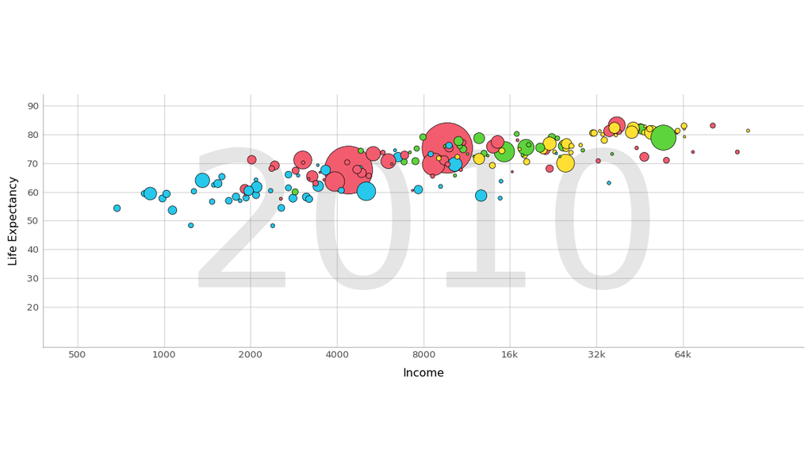

```python
df = pd.read_csv("C:/Users/tyler/Downloads/q1data.csv")
df = df.dropna()

xmin, xmax = 500, 128000
xmid = np.sqrt(xmin * xmax)
ymid = 45

(ggplot(df,
aes(
  x = "income",
  y = "life_exp",
  fill = "four_regions",
  size = "population"
))
+ annotate(
        "text", x=xmid, y=ymid,
        label=str(df["year"].iloc[0]),
        size=100,
        alpha=0.2,
        color="grey",
        ha="center", va="center"
    )
+ geom_point(shape='o', stroke=0.15, color="black")
+ scale_fill_manual(
    values={
        "americas": "#5DD43C",
        "africa": "#27C8EB",
        "europe": "#FFE032",
        "asia": "#F25C6E"
        }
    )
+ scale_x_log10(
        name='Income',
        limits=(xmin, xmax),
        breaks=[500, 1000, 2000, 4000, 8000, 16000, 32000, 64000],
        labels=["500", "1000", "2000", "4000", "8000", "16k", "32k", "64k"]
    )
+ scale_y_continuous(
        name='Life Expectancy',
        limits=(10, 90),
        breaks=list(range(20, 91, 10)),
    )
+ scale_size(range=[0.5, 15])
+ coord_fixed(ratio=0.01)
+ theme(
        panel_background=element_rect(fill="white", color="white"),
        panel_border=element_blank(),
        plot_background=element_rect(fill="white", color="white"),
        panel_grid_major=element_line(color="grey", size=0.5, alpha=0.3),
        panel_grid_minor=element_blank(),
        axis_ticks=element_blank(),
        axis_title=element_text(size=6),
        axis_text=element_text(size=5),
        axis_line=element_line(color="grey", size=0.5, alpha=0.5),
        legend_position="none"
    )
)
```

4. Alternative plot, a plot that focuses on the relationship between income and life_exp could work well, however the initial plot somewhat does this and displays population, making it cleaner and more digestible.

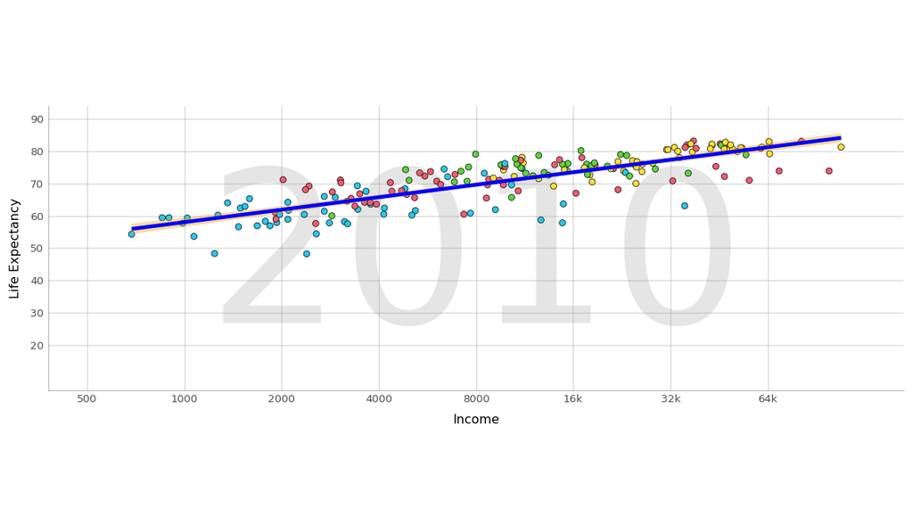

```python
(ggplot(df,
aes(
  x = "income",
  y = "life_exp",
  fill = "four_regions"
))
+ annotate(
        "text", x=xmid, y=ymid,
        label=str(df["year"].iloc[0]),
        size=100,
        alpha=0.2,
        color="grey",
        ha="center", va="center"
    )
+ geom_point(shape='o', stroke=0.15, color="black")
+ geom_smooth(method="lm", color="blue", fill="orange")
+ scale_x_log10(
        name='Income',
        limits=(xmin, xmax),
        breaks=[500, 1000, 2000, 4000, 8000, 16000, 32000, 64000],
        labels=["500", "1000", "2000", "4000", "8000", "16k", "32k", "64k"]
    )
+ scale_y_continuous(
        name='Life Expectancy',
        limits=(10, 90),
        breaks=list(range(20, 91, 10)),
    )
+ scale_size(range=[0.5, 15])
+ coord_fixed(ratio=0.01)
+ theme(
        panel_background=element_rect(fill="white", color="white"),
        panel_border=element_blank(),
        plot_background=element_rect(fill="white", color="white"),
        panel_grid_major=element_line(color="grey", size=0.5, alpha=0.3),
        panel_grid_minor=element_blank(),
        axis_ticks=element_blank(),
        axis_title=element_text(size=6),
        axis_text=element_text(size=5),
        axis_line=element_line(color="grey", size=0.5, alpha=0.5),
        legend_position="none"
    )
+ scale_fill_manual(
    values={
        "americas": "#5DD43C",
        "africa": "#27C8EB",
        "europe": "#FFE032",
        "asia": "#F25C6E"
        }
    )
)
```

# Task 2

1. The aesthetics being used in this graph are:
   - Set y-axis scale
   - Set x-axis scale
   - White background with grey gridlines
   - Points are colored by region
   - Point size is scaled by energy usage
   - Large text display of the year in background
   - X-axis is around twice as long as y-axis is tall
   - Y-axis begins below 0 to allow all countries to fit inside the plot
   - No legend
2. Data downloaded
3. Recreation of the plot:

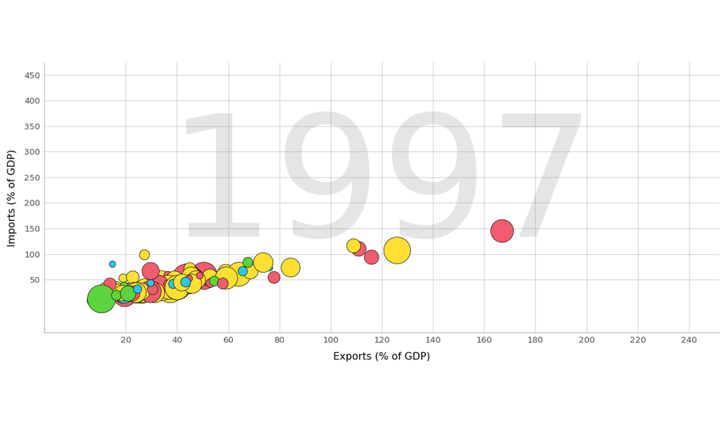

```python
df = pd.read_csv("C:/Users/tyler/Downloads/q2data.csv")
df = df.dropna()

df["energy"] = (
    df["energy"]
    .astype(str)
    .str.replace("k", "", regex=False)
    .astype(float) * 1000
).astype(int)

xmid = 120
ymid = 225

(ggplot(df,
aes(
  x = "exports",
  y = "imports",
  fill = "four_regions",
  size = "energy"
))
+ annotate(
        "text", x=xmid, y=ymid,
        label=str(df["year"].iloc[0]),
        size=100,
        alpha=0.2,
        color="grey",
        ha="center", va="center"
    )
+ geom_point(shape='o', stroke=0.15, color="black")
+ scale_x_continuous(
        name='Exports (% of GDP)',
        limits=(0, 240),
        breaks=list(range(20, 241, 20))
    )
+ scale_y_continuous(
        name='Imports (% of GDP)',
        limits=(-30, 450),
        breaks=list(range(50, 451, 50)),
    )
+ scale_size(range=[0.2, 10])
+ coord_fixed(ratio=0.2)
+ theme(
        panel_background=element_rect(fill="white", color="white"),
        panel_border=element_blank(),
        plot_background=element_rect(fill="white", color="white"),
        panel_grid_major=element_line(color="grey", size=0.5, alpha=0.3),
        panel_grid_minor=element_blank(),
        axis_ticks=element_blank(),
        axis_title=element_text(size=6),
        axis_text=element_text(size=5),
        axis_line=element_line(color="grey", size=0.5, alpha=0.5),
        legend_position="none"
    )
+ scale_fill_manual(
    values={
        "americas": "#5DD43C",
        "africa": "#27C8EB",
        "europe": "#FFE032",
        "asia": "#F25C6E"
        }
    )
)
```

4. Alternative plot, a plot that shows the trade imbalance for each country by plotting a line with slope of 1 between imports and exports would be useful, but you aren’t able to see each country because of how overlapping they are.

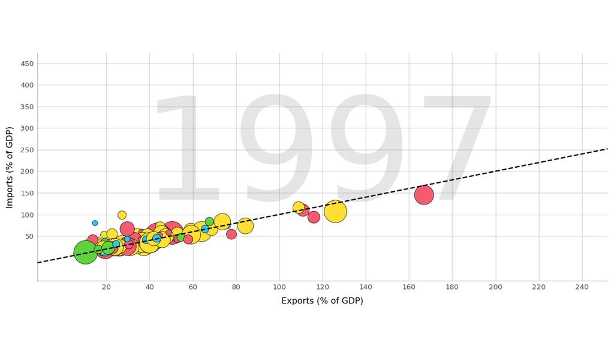

```python
xmid = 120
ymid = 225

(ggplot(df,
aes(
  x = "exports",
  y = "imports",
  fill = "four_regions",
  size = "energy"
))
+ annotate(
        "text", x=xmid, y=ymid,
        label=str(df["year"].iloc[0]),
        size=100,
        alpha=0.2,
        color="grey",
        ha="center", va="center"
    )
+ geom_point(shape='o', stroke=0.15, color="black")
+ scale_x_continuous(
        name='Exports (% of GDP)',
        limits=(0, 240),
        breaks=list(range(20, 241, 20))
    )
+ scale_y_continuous(
        name='Imports (% of GDP)',
        limits=(-30, 450),
        breaks=list(range(50, 451, 50)),
    )
+ scale_size(range=[0.2, 10])
+ coord_fixed(ratio=0.2)
+ theme(
        panel_background=element_rect(fill="white", color="white"),
        panel_border=element_blank(),
        plot_background=element_rect(fill="white", color="white"),
        panel_grid_major=element_line(color="grey", size=0.5, alpha=0.3),
        panel_grid_minor=element_blank(),
        axis_ticks=element_blank(),
        axis_title=element_text(size=6),
        axis_text=element_text(size=5),
        axis_line=element_line(color="grey", size=0.5, alpha=0.5),
        legend_position="none"
    )
+ scale_fill_manual(
    values={
        "americas": "#5DD43C",
        "africa": "#27C8EB",
        "europe": "#FFE032",
        "asia": "#F25C6E"
        }
    )
+ geom_abline(slope=1, intercept=0, linetype="dashed")
)
```

# Task 3

1. The aesthetics being used in this graph are:
   - Logarithmic y-axis scale
   - Set x-axis scale
   - White background with grey gridlines
   - Minor gridlines at 300, 400, … 80k, 90k
   - Points are colored by region
   - Point size is scaled by income
   - Large text display of the year in background
   - X-axis is around twice as long as y-axis is tall
   - No legend
2. Data downloaded
3. Recreation of the plot:

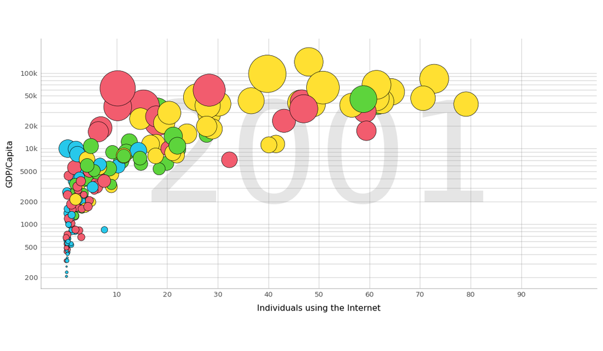

```python
df = pd.read_csv("C:/Users/tyler/Downloads/q3data.csv")
df = df.dropna()

ymin, ymax = 200, 200000
ymid = np.sqrt(ymin * ymax)
xmid = 50

major_breaks = [200, 500, 1000, 2000, 5000, 10000, 20000, 50000, 100000]
minor_breaks = [300, 400, 600, 700, 800, 900, 3000, 4000, 6000, 7000, 8000, 9000, 30000, 40000, 60000, 70000, 80000, 90000]

(ggplot(df,
aes(
  x = "internet_users",
  y = "gdp",
  fill = "four_regions",
  size = "income"
))
+ annotate(
        "text", x=xmid, y=ymid,
        label=str(df["year"].iloc[0]),
        size=100,
        alpha=0.2,
        color="grey",
        ha="center", va="center"
    )
+ geom_point(shape='o', stroke=0.15, color="black")
+ scale_fill_manual(
    values={
        "americas": "#5DD43C",
        "africa": "#27C8EB",
        "europe": "#FFE032",
        "asia": "#F25C6E"
        }
    )
+ scale_y_log10(
        name='GDP/Capita',
        limits=(ymin, ymax),
        breaks=major_breaks,
        minor_breaks=minor_breaks,
        labels=["200", "500", "1000", "2000", "5000", "10k", "20k", "50k", "100k"]
    )
+ scale_x_continuous(
        name='Individuals using the Internet',
        limits=(0, 100),
        breaks=list(range(10, 91, 10)),
        minor_breaks=[]
    )
+ scale_size(range=[0.5, 15])
+ coord_fixed(ratio=15)
+ theme(
        panel_background=element_rect(fill="white", color="white"),
        panel_border=element_blank(),
        plot_background=element_rect(fill="white", color="white"),
        panel_grid_major=element_line(color="grey", size=0.5, alpha=0.3),
        panel_grid_minor=element_line(color="grey", size=0.5, alpha=0.3),
        axis_ticks=element_blank(),
        axis_title=element_text(size=6),
        axis_text=element_text(size=5),
        axis_line=element_line(color="grey", size=0.5, alpha=0.5),
        legend_position="none"
    )
)
```

4. Alternative plot, a bin plot can show a similar level of detail as the point plot, however it loses the details of the income of each country as well as the region of each country.

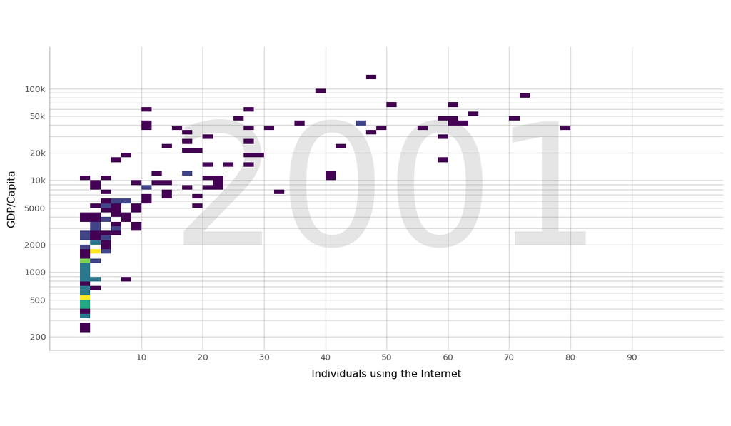

```python
(ggplot(df,
aes(
  x = "internet_users",
  y = "gdp"
))
+ annotate(
        "text", x=xmid, y=ymid,
        label=str(df["year"].iloc[0]),
        size=100,
        alpha=0.2,
        color="grey",
        ha="center", va="center"
    )
+ geom_bin2d(bins=60)
+ scale_y_log10(
        name='GDP/Capita',
        limits=(ymin, ymax),
        breaks=major_breaks,
        minor_breaks=minor_breaks,
        labels=["200", "500", "1000", "2000", "5000", "10k", "20k", "50k", "100k"]
    )
+ scale_x_continuous(
        name='Individuals using the Internet',
        limits=(0, 100),
        breaks=list(range(10, 91, 10)),
        minor_breaks=[]
    )
+ scale_size(range=[0.5, 15])
+ coord_fixed(ratio=15)
+ theme(
        panel_background=element_rect(fill="white", color="white"),
        panel_border=element_blank(),
        plot_background=element_rect(fill="white", color="white"),
        panel_grid_major=element_line(color="grey", size=0.5, alpha=0.3),
        panel_grid_minor=element_line(color="grey", size=0.5, alpha=0.3),
        axis_ticks=element_blank(),
        axis_title=element_text(size=6),
        axis_text=element_text(size=5),
        axis_line=element_line(color="grey", size=0.5, alpha=0.5),
        legend_position="none"
    )
)
```